# If using the code for: Growth categories and birth weight, within-animal growth response, and projection to market weight, please cite the paper

Manuscript: *Increasing the threonine-to-lysine ratio improves the growth performance of slow-growing pigs within group precision feeding*. Submitted to the *Journal of Animal Science* (2026).

Dr Aline Remus

27 August 2026

# 1 Citation

When using the code for **growth categories and birth weight**, **within-animal growth response**, or **projection to market weight**, please cite:

Pedro Righetti Arnaut, Candido Pomar, Luciano Hauschild, and Aline Remus (2026). *Increasing the threonine-to-lysine ratio improves the growth performance of slow-growing pigs within group precision feeding*. Manuscript submitted to the *Journal of Animal Science*.

**Corresponding author:** aline.remus@agr.gc.ca  
**Additional email:** alnremus@gmail.com

## 1.1 Analytical principle

The analysis follows each pig across growth phases and compares treatment responses within predefined growth-rate categories. Using each pig’s pre-trial growth as its own baseline helps separate the dietary response from its previous growth trajectory. Market-weight projections extend the observed growth rates and use bootstrap resampling to describe their uncertainty; they are not direct measurements at 120 kg.

Base R only. No packages are needed to run the analyses; `rmarkdown` and `knitr` are needed only to knit this file.

Two input files, both in the same folder as this document:

- `growth_rates_all_phases.csv` — one row per pig per phase, 59 pigs x 4 phases.
- `feed_cost_by_pig.csv` — one row per pig, feed cost over the 21-d period.

Treatments are conventional phase feeding at 100% of the ideal threonine to lysine ratio of 0.65 (`CPF100`) and group precision feeding at 80, 100, 120 and 140% of that ratio (`GPF80`, `GPF100`, `GPF120`, `GPF140`). Growth-rate categories (`Gr`) are Fast, Medium, Slow.

# 2 Data

```r
raw <- read.csv("growth_rates_all_phases.csv")
str(raw)
```

```
## 'data.frame':    236 obs. of  13 variables:
##  $ Pig                      : int  2 5 6 7 10 13 17 18 19 21 ...
##  $ Sex                      : chr  "M" "M" "M" "F" ...
##  $ Treatment                : chr  "GPF80" "GPF100" "GPF80" "GPF100" ...
##  $ Growth                   : chr  "Fast" "Fast" "Fast" "Fast" ...
##  $ Phase                    : chr  "Birth-weaning" "Birth-weaning" "Birth-weaning" "Birth-weaning" ...
##  $ Age_start                : int  0 0 0 0 0 0 0 0 0 0 ...
##  $ Age_end                  : int  21 21 21 21 21 21 21 21 21 21 ...
##  $ Days                     : int  21 21 21 21 21 21 21 21 21 21 ...
##  $ BW_start_kg              : num  2.02 1.75 1.79 1.59 1.28 ...
##  $ BW_end_kg                : num  7.67 8.76 8.42 9.23 6.43 ...
##  $ ADG_kg_d                 : num  0.269 0.334 0.316 0.364 0.245 ...
##  $ Relative_growth_pct_d    : num  6.35 7.66 7.37 8.36 7.67 ...
##  $ Gain_per_initial_BW_pct_d: num  13.3 19 17.6 22.8 19.1 ...
```

```r
table(raw$Phase)
```

```
##
##     Birth-weaning   Selection-start         Treatment Weaning-selection
##                59                59                59                59
```

```r
ORDER <- c("CPF100", "GPF80", "GPF100", "GPF120", "GPF140")
GRP   <- c("Fast", "Medium", "Slow")

# one row per pig, with the quantities used below
wide <- function(ph, cols) {
  s <- raw[raw$Phase == ph, ]
  s <- s[order(s$Pig), cols]
  s
}
b <- wide("Birth-weaning",     c("Pig","Sex","Treatment","Growth","BW_start_kg","BW_end_kg","ADG_kg_d"))
n <- wide("Weaning-selection", c("Pig","BW_end_kg","ADG_kg_d"))
p <- wide("Selection-start",   c("Pig","BW_end_kg","ADG_kg_d"))
t <- wide("Treatment",         c("Pig","BW_end_kg","ADG_kg_d"))

d <- data.frame(
  Pig       = b$Pig,
  Sex       = b$Sex,
  Treatment = factor(b$Treatment, levels = ORDER),
  Gr        = factor(b$Growth,    levels = GRP),
  bw_birth  = b$BW_start_kg,
  bw_wean   = b$BW_end_kg,
  bw_sel    = n$BW_end_kg,
  bw_d1     = p$BW_end_kg,
  bw_end    = t$BW_end_kg,
  adg_suck  = b$ADG_kg_d,
  adg_nurs  = n$ADG_kg_d,
  adg_pre   = p$ADG_kg_d,
  adg_trial = t$ADG_kg_d
)
d$cell  <- interaction(d$Treatment, d$Gr, drop = TRUE)
d$dADG  <- d$adg_trial - d$adg_pre     # within-animal change, kg/d
nrow(d)
```

```
## [1] 59
```

A convenience function for mean and standard error.

```r
mse <- function(x) c(mean = mean(x), sem = sd(x) / sqrt(length(x)))
cellmeans <- function(v, f1 = d$Treatment, f2 = d$Gr) tapply(v, list(f1, f2), mean)
```

# 3 Are the growth-rate categories birth-weight categories?

The categories were formed from pre-trial average daily gain. The question is whether they also separate the pigs by birth weight, that is, whether the slow growers are the low-birth-weight animals of the population.

```r
round(t(sapply(GRP, function(g) c(
  n          = sum(d$Gr == g),
  birth      = mean(d$bw_birth[d$Gr == g]),
  birth_sem  = sd(d$bw_birth[d$Gr == g]) / sqrt(sum(d$Gr == g)),
  weaning    = mean(d$bw_wean[d$Gr == g]),
  bw_d1      = mean(d$bw_d1[d$Gr == g])
))), 3)
```

```
##         n birth birth_sem weaning  bw_d1
## Fast   20 1.518     0.068   7.732 45.760
## Medium 19 1.517     0.047   7.344 44.484
## Slow   20 1.414     0.063   6.920 43.700
```

```r
summary(aov(bw_birth ~ Gr, data = d))
```

```
##             Df Sum Sq Mean Sq F value Pr(>F)
## Gr           2  0.143 0.07142   0.985   0.38
## Residuals   56  4.059 0.07248
```

```r
summary(aov(bw_wean  ~ Gr, data = d))
```

```
##             Df Sum Sq Mean Sq F value Pr(>F)
## Gr           2   6.59   3.295   2.675 0.0777 .
## Residuals   56  68.98   1.232
## ---
## Signif. codes:  0 '***' 0.001 '**' 0.01 '*' 0.05 '.' 0.1 ' ' 1
```

```r
summary(aov(bw_d1    ~ Gr, data = d))
```

```
##             Df Sum Sq Mean Sq F value Pr(>F)
## Gr           2   43.2   21.61   1.717  0.189
## Residuals   56  704.9   12.59
```

Correlation of birth weight with each later trait.

```r
targets <- c(adg_suck = "ADG birth to weaning", adg_nurs = "ADG weaning to selection",
             adg_pre  = "pre-trial ADG",        bw_d1    = "BW at d 1",
             adg_trial= "ADG during the trial")
do.call(rbind, lapply(names(targets), function(k) {
  ct <- cor.test(d$bw_birth, d[[k]])
  data.frame(trait = targets[[k]], r = round(unname(ct$estimate), 3),
             r2 = round(unname(ct$estimate)^2, 3), P = signif(ct$p.value, 3))
}))
```

| trait | r | r2 | P |
| --- | --- | --- | --- |
| ADG birth to weaning | 0.192 | 0.037 | 0.14500 |
| ADG weaning to selection | 0.259 | 0.067 | 0.04790 |
| pre-trial ADG | 0.368 | 0.135 | 0.00416 |
| BW at d 1 | 0.392 | 0.154 | 0.00215 |
| ADG during the trial | 0.363 | 0.132 | 0.00472 |

Cross-classification of birth-weight tertile against the assigned category.

```r
cut3 <- quantile(d$bw_birth, c(1/3, 2/3))
d$bw_tertile <- cut(d$bw_birth, c(-Inf, cut3, Inf), labels = c("light","mid","heavy"))
round(cut3, 2)
```

```
## 33.33333% 66.66667%
##      1.36      1.59
```

```r
tab <- table(d$bw_tertile, d$Gr)
tab
```

```
##
##         Fast Medium Slow
##   light    7      6    8
##   mid      4      7    7
##   heavy    9      6    5
```

```r
chisq.test(tab)
```

```
##
##  Pearson's Chi-squared test
##
## data:  tab
## X-squared = 2.5276, df = 4, p-value = 0.6397
```

# 4 When did the body weight advantage of the GPF140 slow growers appear?

```r
sl <- d[d$Gr == "Slow", ]
round(do.call(rbind, lapply(ORDER, function(tr) {
  s <- sl[sl$Treatment == tr, ]
  c(n = nrow(s), birth = mean(s$bw_birth), weaning = mean(s$bw_wean),
    selection = mean(s$bw_sel), d1 = mean(s$bw_d1))
})), 2) -> tabsl
rownames(tabsl) <- ORDER; tabsl
```

```
##        n birth weaning selection    d1
## CPF100 4  1.28    6.53     26.52 41.20
## GPF80  4  1.41    7.30     28.35 43.52
## GPF100 4  1.41    6.09     28.12 43.25
## GPF120 4  1.20    6.53     28.05 43.33
## GPF140 4  1.77    8.16     31.75 47.20
```

```r
for (k in c("bw_birth","bw_wean","bw_sel","bw_d1")) {
  f <- summary(aov(sl[[k]] ~ sl$Treatment))[[1]]
  cat(sprintf("%-9s F(%d,%d) = %5.2f   P = %.3f   GPF140 - CPF100 = %+6.2f kg\n",
              k, f$Df[1], f$Df[2], f$`F value`[1], f$`Pr(>F)`[1],
              mean(sl[[k]][sl$Treatment == "GPF140"]) -
              mean(sl[[k]][sl$Treatment == "CPF100"])))
}
```

```
## bw_birth  F(4,15) =  3.64   P = 0.029   GPF140 - CPF100 =  +0.49 kg
## bw_wean   F(4,15) =  2.28   P = 0.108   GPF140 - CPF100 =  +1.63 kg
## bw_sel    F(4,15) =  1.09   P = 0.398   GPF140 - CPF100 =  +5.23 kg
## bw_d1     F(4,15) =  1.15   P = 0.372   GPF140 - CPF100 =  +6.00 kg
```

Average daily gain of the slow growers in each interval, before and during the trial.

```r
round(do.call(rbind, lapply(ORDER, function(tr) {
  s <- sl[sl$Treatment == tr, ]
  c(suckling = mean(s$adg_suck), nursery = mean(s$adg_nurs),
    pre_trial = mean(s$adg_pre), trial = mean(s$adg_trial))
})), 3) -> tabadg
rownames(tabadg) <- ORDER; tabadg
```

```
##        suckling nursery pre_trial trial
## CPF100    0.250   0.454     0.978 1.021
## GPF80     0.280   0.478     1.012 0.995
## GPF100    0.223   0.501     1.008 1.067
## GPF120    0.253   0.489     1.018 1.165
## GPF140    0.304   0.536     1.030 1.246
```

# 5 Within-animal change in average daily gain

Each pig is its own baseline, so a growth trajectory established before the diets were applied cancels out.

```r
round(cellmeans(1000 * d$dADG), 0)          # g/d
```

```
##        Fast Medium Slow
## CPF100  161     94   43
## GPF80    39    188  -16
## GPF100  354     91   58
## GPF120   58     65  147
## GPF140   49    218  216
```

```r
round(tapply(1000 * d$dADG, list(d$Treatment, d$Gr),
             function(x) sd(x)/sqrt(length(x))), 0)   # SEM
```

```
##        Fast Medium Slow
## CPF100   80     52   37
## GPF80    75     70   45
## GPF100   47     81   62
## GPF120   73     45   77
## GPF140   27     47   78
```

```r
for (g in GRP) {
  s <- d[d$Gr == g, ]
  f <- summary(aov(dADG ~ Treatment, data = s))[[1]]
  gp <- s[s$Treatment != "CPF100", ]
  ratio <- c(GPF80 = 0.8, GPF100 = 1.0, GPF120 = 1.2, GPF140 = 1.4)[as.character(gp$Treatment)]
  lin <- summary(lm(dADG ~ ratio, data = data.frame(dADG = gp$dADG, ratio = ratio)))
  cat(sprintf("%-7s treatment P = %.3f | linear Thr trend within GPF P = %.3f | GPF140 - CPF100 = %+4.0f g/d\n",
              g, f$`Pr(>F)`[1], coef(lin)[2, 4],
              1000 * (mean(s$dADG[s$Treatment == "GPF140"]) -
                      mean(s$dADG[s$Treatment == "CPF100"]))))
}
```

```
## Fast    treatment P = 0.015 | linear Thr trend within GPF P = 0.513 | GPF140 - CPF100 = -111 g/d
## Medium  treatment P = 0.331 | linear Thr trend within GPF P = 0.718 | GPF140 - CPF100 = +124 g/d
## Slow    treatment P = 0.120 | linear Thr trend within GPF P = 0.013 | GPF140 - CPF100 = +173 g/d
```

# 6 Projection to a 120 kg body weight

Nothing was observed at 120 kg. The trial lasted 21 d; what follows is what the measured average daily gain would imply if it continued unchanged. Two bases are computed.

**Basis 1, cell ADG adjusted for initial body weight.** Average daily gain is adjusted to a common initial body weight by the pooled within-cell regression of ADG on initial body weight, and the projection starts from that common weight.

**Basis 2, within-animal change.** For each cell, ADG is the mean pre-trial ADG of the category plus the mean within-animal change of that cell. Differences among treatments then come only from the change each animal showed when the diets were applied.

```r
ancova_slope <- function(df) {
  num <- den <- 0
  for (cl in levels(droplevels(df$cell))) {
    s <- df[df$cell == cl, ]
    num <- num + sum((s$bw_d1 - mean(s$bw_d1)) * (s$adg_trial - mean(s$adg_trial)))
    den <- den + sum((s$bw_d1 - mean(s$bw_d1))^2)
  }
  num / den
}

days_basis1 <- function(df) {                       # days from the END of the period
  B <- mean(df$bw_d1); bta <- ancova_slope(df)
  out <- matrix(NA, length(ORDER), length(GRP), dimnames = list(ORDER, GRP))
  for (tr in ORDER) for (g in GRP) {
    s <- df[df$Treatment == tr & df$Gr == g, ]
    adg <- mean(s$adg_trial) + bta * (B - mean(s$bw_d1))
    out[tr, g] <- (120 - B) / adg - 21
  }
  out
}

days_basis2 <- function(df) {
  out <- matrix(NA, length(ORDER), length(GRP), dimnames = list(ORDER, GRP))
  for (g in GRP) {
    sg   <- df[df$Gr == g, ]
    preg <- mean(sg$adg_pre); bwg <- mean(sg$bw_d1)
    for (tr in ORDER) {
      s   <- sg[sg$Treatment == tr, ]
      adg <- preg + mean(s$dADG)
      out[tr, g] <- (120 - (bwg + 21 * adg)) / adg
    }
  }
  out
}

round(days_basis1(d), 1)
```

```
##        Fast Medium Slow
## CPF100 37.6   45.5 52.1
## GPF80  40.9   40.8 54.5
## GPF100 37.3   44.9 49.4
## GPF120 43.4   46.5 43.5
## GPF140 43.1   38.3 39.8
```

```r
round(days_basis2(d), 1)
```

```
##        Fast Medium Slow
## CPF100 37.9   45.2 51.5
## GPF80  44.3   40.2 55.8
## GPF100 30.1   45.4 50.5
## GPF120 43.2   47.0 45.0
## GPF140 43.7   38.8 41.2
```

## 6.1 Bootstrap

Whole animals are resampled with replacement within each treatment x growth-rate cell. The random number generator differs from the one used in the Python implementation, so intervals reproduce to within about a tenth of a day rather than exactly.

```r
set.seed(20260827)
R <- 4000
boot1 <- boot2 <- array(NA, c(R, length(ORDER), length(GRP)),
                        dimnames = list(NULL, ORDER, GRP))
cells <- split(seq_len(nrow(d)), d$cell)
for (i in seq_len(R)) {
  idx <- unlist(lapply(cells, function(ix) sample(ix, length(ix), replace = TRUE)))
  bd  <- d[idx, ]
  boot1[i, , ] <- days_basis1(bd)
  boot2[i, , ] <- days_basis2(bd)
}

contrast <- function(bt) {
  out <- do.call(rbind, lapply(GRP, function(g)
    do.call(rbind, lapply(setdiff(ORDER, "CPF100"), function(tr) {
      v <- bt[, "CPF100", g] - bt[, tr, g]
      data.frame(Gr = g, Treatment = tr, median = round(median(v), 1),
                 lower = round(quantile(v, .025), 1),
                 upper = round(quantile(v, .975), 1), row.names = NULL)
    }))))
  out
}
contrast(boot1)   # basis 1
```

| Gr | Treatment | median | lower | upper |
| --- | --- | --- | --- | --- |
| Fast | GPF80 | -3.4 | -10.6 | 3.1 |
| Fast | GPF100 | 0.6 | -5.6 | 5.7 |
| Fast | GPF120 | -5.5 | -12.4 | 0.1 |
| Fast | GPF140 | -5.3 | -11.6 | 0.1 |
| Medium | GPF80 | 4.7 | -2.9 | 13.2 |
| Medium | GPF100 | 0.6 | -8.3 | 9.9 |
| Medium | GPF120 | -1.0 | -9.1 | 7.1 |
| Medium | GPF140 | 7.3 | 0.6 | 15.1 |
| Slow | GPF80 | -2.5 | -7.1 | 3.4 |
| Slow | GPF100 | 2.7 | -6.0 | 10.1 |
| Slow | GPF120 | 8.7 | 4.2 | 13.6 |
| Slow | GPF140 | 12.3 | 4.6 | 19.4 |

```r
contrast(boot2)   # basis 2
```

| Gr | Treatment | median | lower | upper |
| --- | --- | --- | --- | --- |
| Fast | GPF80 | -6.3 | -16.7 | 2.5 |
| Fast | GPF100 | 8.1 | 0.9 | 14.5 |
| Fast | GPF120 | -5.1 | -15.2 | 3.5 |
| Fast | GPF140 | -5.6 | -12.4 | 0.8 |
| Medium | GPF80 | 5.0 | -2.4 | 12.8 |
| Medium | GPF100 | -0.1 | -10.7 | 8.6 |
| Medium | GPF120 | -1.7 | -8.9 | 5.0 |
| Medium | GPF140 | 6.7 | -0.3 | 12.9 |
| Slow | GPF80 | -4.3 | -12.3 | 2.0 |
| Slow | GPF100 | 1.0 | -7.5 | 8.8 |
| Slow | GPF120 | 6.6 | -3.0 | 14.9 |
| Slow | GPF140 | 10.2 | 1.5 | 18.0 |

## 6.2 Figure: projected trajectories

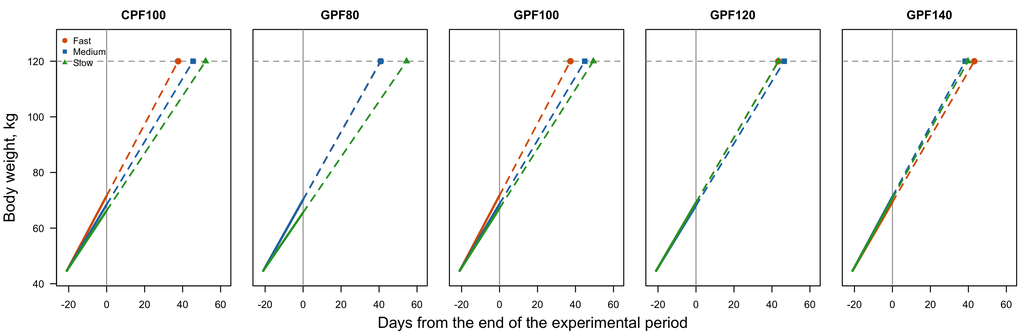

```r
B   <- mean(d$bw_d1); bta <- ancova_slope(d)
col <- c(Fast = "#d95f02", Medium = "#1f77b4", Slow = "#2ca02c")
pch <- c(Fast = 19, Medium = 15, Slow = 17)
op  <- par(mfrow = c(1, 5), mar = c(4, 1.2, 2.4, 0.6), oma = c(0, 3.4, 0, 0), las = 1)
for (tr in ORDER) {
  plot(NA, xlim = c(-23, 62), ylim = c(B - 2, 128), xlab = "", ylab = "",
       main = tr, yaxt = if (tr == ORDER[1]) "s" else "n")
  abline(h = 120, lty = 2, col = "grey60"); abline(v = 0, col = "grey60")
  for (g in GRP) {
    s   <- d[d$Treatment == tr & d$Gr == g, ]
    adg <- mean(s$adg_trial) + bta * (B - mean(s$bw_d1))
    dd  <- (120 - B) / adg - 21
    lines(c(-21, 0), B + adg * c(0, 21), col = col[g], lwd = 2.4)
    lines(c(0, dd),  B + adg * c(21, dd + 21), col = col[g], lwd = 1.8, lty = 2)
    points(dd, 120, col = col[g], pch = pch[g], cex = 1.2)
  }
  if (tr == ORDER[1]) legend("topleft", GRP, col = col[GRP], pch = pch[GRP],
                             bty = "n", cex = 0.9)
}
mtext("Body weight, kg", side = 2, outer = TRUE, line = 2, las = 0)
mtext("Days from the end of the experimental period", side = 1, outer = TRUE, line = -1.4)
```

```r
par(op)
```

# 7 Feed cost over the experimental period

Each pig’s daily blend priced with 2025 reference ingredient costs. The prices are not current, so only the comparison among treatments should be read from them.

## 7.1 Ingredient reference costs — editable upstream inputs

The following values document the ingredient prices used upstream to prepare `feed_cost_by_pig.csv`. They are shown here to make the assumptions transparent and easy to revise. **Editing this table alone does not recalculate the results below**; after changing an ingredient price, the upstream feed-cost calculation and `feed_cost_by_pig.csv` must also be updated.

Values of `$0.000` for soybean hulls, salt, and choline chloride are placeholders for missing prices, not evidence that these ingredients have no cost. Until invoice or reference prices are entered, absolute feed costs may be underestimated.

| Ingredient | Cost, USD/t | Cost, USD/kg | Source | Source / note | Used in upstream formulas? | Input status |
| --- | --- | --- | --- | --- | --- | --- |
| Corn | $201.760 | $0.202 | Statistics Canada, 2025 | [Statistics Canada table 32-10-0077-01](https://doi.org/10.25318/3210007701-eng) | Yes | Provided |
| Wheat | $254.060 | $0.254 | Statistics Canada, 2025 | [Statistics Canada table 32-10-0077-01](https://doi.org/10.25318/3210007701-eng) | Yes | Provided |
| Wheat shorts | $108.930 | $0.109 | USDA, 2025 | USDA *National Mill-Feeds and Miscellaneous Feedstuff Report* (as cited in the supplied document) | No | Provided |
| Timothy meal | $335.000 | $0.335 | USDA, 2025 | USDA *National Mill-Feeds and Miscellaneous Feedstuff Report* (as cited in the supplied document) | No | Provided |
| Soybean meal | $408.090 | $0.408 | Statistics Canada, 2025 | [Statistics Canada table 32-10-0077-01](https://doi.org/10.25318/3210007701-eng) | Yes | Provided |
| Limestone | $1,800.000 | $1.800 | Calculated[^1] | Calculated by difference of inclusion into experimental diets (supplied Table S1.1 footnote) | Yes | Provided |
| Animal fat | $1,247.600 | $1.248 | Statistics Canada, 2025 | [Statistics Canada table 32-10-0077-01](https://doi.org/10.25318/3210007701-eng) | No | Provided |
| L-Lysine | $1,888.000 | $1.888 | All About Feed, 2025b | [Lysine HCl market price](https://www.allaboutfeed.net/market-prices/lysine-hcl/) | Yes | Provided |
| L-Tryptophan | $6,750.000 | $6.750 | All About Feed, 2025b | All About Feed, 2025b, as supplied; the bibliography in the supplied document points to the L-Lysine HCl page | Yes | Provided |
| DL-Methionine | $3,230.000 | $3.230 | All About Feed, 2025a | [DL-Methionine market price](https://www.allaboutfeed.net/market-prices/dl-methionine/) | Yes | Provided |
| L-Threonine | $2,080.000 | $2.080 | All About Feed, 2025c | [Threonine market price](https://www.allaboutfeed.net/market-prices/threonine/) | Yes | Provided |
| L-Valine | $10,000.000 | $10.000 | All About Feed, 2025b | All About Feed, 2025b, as supplied; the bibliography in the supplied document points to the L-Lysine HCl page | Yes | Provided |
| Vitamin-mineral complex | $10,000.000 | $10.000 | Calculated[^2] | Calculated by difference of inclusion into experimental diets (supplied Table S1.1 footnote) | Yes | Provided |
| Monocalcium phosphate | $2,500.000 | $2.500 | Calculated[^3] | Calculated by difference of inclusion into experimental diets (supplied Table S1.1 footnote) | Yes | Provided |
| Phytase | $2,000.000 | $2.000 | Calculated[^4] | Calculated by difference of inclusion into experimental diets (supplied Table S1.1 footnote) | Yes | Provided |
| Soybean hulls | $0.000 | $0.000 | Not provided | Not available in the supplied reference-cost table | Yes | **Missing — enter invoice/reference price** |
| Salt | $0.000 | $0.000 | Not provided | Not available in the supplied reference-cost table | Yes | **Missing — enter invoice/reference price** |
| Choline chloride | $0.000 | $0.000 | Not provided | Not available in the supplied reference-cost table | Yes | **Missing — enter invoice/reference price** |

```r
fc <- read.csv("feed_cost_by_pig.csv")
fc$Treatment <- factor(fc$Treatment, levels = ORDER)
fc$Growth    <- factor(fc$Growth,    levels = GRP)
fc$per_day   <- fc$Feed_cost_USD_21d / fc$Days

round(tapply(fc$per_day, list(fc$Treatment, fc$Growth), mean), 3)
```

```
##         Fast Medium  Slow
## CPF100 0.979  0.831 0.748
## GPF80  0.927  0.897 0.747
## GPF100 0.868  0.797 0.783
## GPF120 0.895  0.863 0.866
## GPF140 0.863  0.933 0.892
```

```r
round(tapply(fc$per_day, fc$Treatment, mean), 3)
```

```
## CPF100  GPF80 GPF100 GPF120 GPF140
##  0.853  0.853  0.816  0.875  0.896
```

```r
round(100 * tapply(fc$per_day, fc$Treatment, mean) /
      mean(fc$per_day[fc$Treatment == "CPF100"]), 1)     # relative to CPF100 = 100
```

```
## CPF100  GPF80 GPF100 GPF120 GPF140
##  100.0  100.1   95.7  102.6  105.1
```

```r
round(tapply(fc$Thr_cost_USD_21d, fc$Treatment, mean), 3)
```

```
## CPF100  GPF80 GPF100 GPF120 GPF140
##  0.160  0.013  0.147  0.286  0.421
```

```r
round(100 * tapply(fc$Thr_cost_USD_21d, fc$Treatment, mean) /
      tapply(fc$Feed_cost_USD_21d, fc$Treatment, mean), 1)   # % of feed cost
```

```
## CPF100  GPF80 GPF100 GPF120 GPF140
##    0.9    0.1    0.9    1.6    2.2
```

[^1]: Calculated value supplied in the source document rather than a directly observed market quotation.
[^2]: Calculated value supplied in the source document rather than a directly observed market quotation.
[^3]: Calculated value supplied in the source document rather than a directly observed market quotation.
[^4]: Calculated value supplied in the source document rather than a directly observed market quotation.